# Material legacies can degrade resilience_model code

Kai Kopecky

4/18/2022

## Overview

The code in this markdown file was used to build, analyze, and visualize a model of coral reef resilience in following disturbances that either do or do not generate standing dead coral skeletons, i.e., a material legacy. This code was used to generate figures 4 and 5 of the manuscript “Material legacies can degrade resilience: Structure-retaining disturbances promote regime shifts on coral reefs”.

### The model

#### State Variables for proportional cover of benthic space holders:

$$\begin{align}
&C_L\ =\ Live\ coral\\
\newline
&C_D\ =\ Dead\ coral\\
\newline
&M_E\ =\ Exposed\ macroalgae\\
\newline
&M_P\ =\ Protected\ macroalgae\\
\newline
&S\ =\ Empty\ space\\
\end{align}$$

#### Ordinary differential equations

Rates of change for proportional spatial cover of live coral, dead coral, and macroalgae on either open substrate or dead coral:
$$\begin{align}
&\frac{d C_L}{dt} = g_c C_L S + \gamma_cS - g_{mC_L} C_L(M_E + M_P) - d_c C_L \\
\newline
&\frac{d C_D}{dt} = d_c C_L + M_P(h(1- p) + d_m) - g_m C_D (M_E + M_P) - \gamma_mC_D- e C_D \\
\newline
&\frac{d M_E}{dt} = g_m M_E S + g_m M_P S + \gamma_mS - M_E(h + d_m)\\
\newline
&\frac{d M_P}{dt} = g_m M_P C_D + g_m M_E C_D + g_{mc} C_L(M_E + M_P) + \gamma_mC_D - M_P(h(1-p) + d_m + e)\\
\newline
&\ S = 1 - C_L - C_D - M_E - M_P \\
\newline
\end{align}$$

#### Figure 4: Time series

Time series for structure-removing disturbance event in which all space-holders are reduced to 50% of their pre-disturbance cover. Starting conditions reflect a coral-dominated community state.

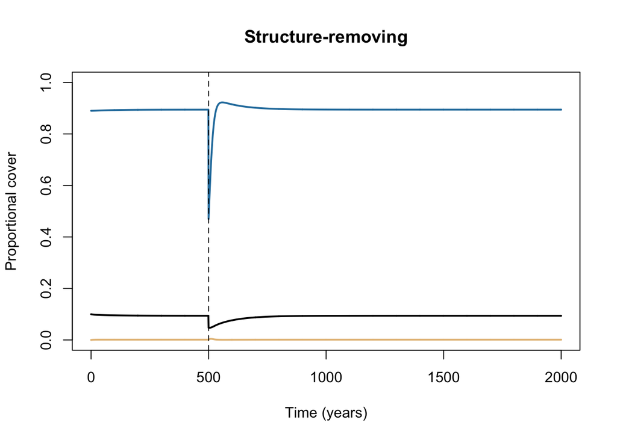

```r
# Create time vector, holding vectors for each state variable, and set initial conditions
C_L.simu_rem <- NaN*tset.disturb; C_L.simu_rem[1] <- 0.89 # Equilibrium value
C_D.simu_rem <- NaN*tset.disturb; C_D.simu_rem[1] <- 0.1 # Equilirbirum value
M_E.simu_rem <- NaN*tset.disturb; M_E.simu_rem[1] <- 0
M_P.simu_rem <- NaN*tset.disturb; M_P.simu_rem[1] <- 0

# For() loop with if/else statement to simulate trajectories of spatial occupancy by live coral and macroalgae before and after disturbance

for(i in 2:length(tset.disturb)){ # For every element after the first in the time vector...

  if(tset.disturb[i] !=t_disturb){ # ...if the time point does not equal the time of disturbance, run the simulation as normal...

  dt <- tset.disturb[i] - tset.disturb[i-1] # calculate change in time

  # Proportional cover at previous time step
  C_L <- C_L.simu_rem[i-1]
  C_D <- C_D.simu_rem[i-1]
  M_E <- M_E.simu_rem[i-1]
  M_P <- M_P.simu_rem[i-1]

  # Change in proportional cover for live coral (C_L), dead coral (C_D), exposed macroalgae (M_E), and protected macroalgae (M_P)
  dC_L <- (dt)*(g_C*C_L*(1-C_L-C_D-M_E-M_P) + gamma_C*(1-C_L-C_D-M_E-M_P) - g_M_P_L*C_L*(M_E + M_P) - d_C*C_L)
  dC_D <- (dt)*(d_C*C_L + M_P*(h_M_E*(1-ref) + d_M) - g_M*C_D*(M_E + M_P) - gamma_M*C_D - e*C_D)
  dM_E <- (dt)*(g_M*M_E*(1-C_L-C_D-M_E-M_P) + g_M*M_P*(1-C_L-C_D-M_E-M_P) + gamma_M*(1-C_L-C_D-M_E-M_P) - M_E*(h_M_E + d_M))
  dM_P <- (dt)*(g_M*M_P*C_D + g_M*M_E*C_D + g_M_P_L*C_L*(M_E + M_P) + gamma_M*C_D - M_P*(h_M_E*(1-ref) + d_M + e))

  # Proportional cover at new time step
  C_L.simu_rem[i] <- C_L.simu_rem[i-1] + dC_L
  C_D.simu_rem[i] <- C_D.simu_rem[i-1] + dC_D
  M_E.simu_rem[i] <- M_E.simu_rem[i-1] + dM_E
  M_P.simu_rem[i] <- M_P.simu_rem[i-1] + dM_P
  }

    else { # ... but if the time step does equal the time of disturbance...

  dt <- tset.disturb[i] - tset.disturb[i-1]

  # reduce all space holders to 50% of their pre-disturbance levels
  C_L <- C_L.simu_rem[i-1]*0.5
  C_D <- C_D.simu_rem[i-1]*0.5
  M_E <- M_E.simu_rem[i-1]*0.5
  M_P <- M_P.simu_rem[i-1]*0.5

  dC_L <- (dt)*(g_C*C_L*(1-C_L-C_D-M_E-M_P) + gamma_C*(1-C_L-C_D-M_E-M_P) - g_M_P_L*C_L*(M_E + M_P) - d_C*C_L)
  dC_D <- (dt)*(d_C*C_L + M_P*(h_M_E*(1-ref) + d_M) - g_M*C_D*(M_E + M_P) - gamma_M*C_D - e*C_D)
  dM_E <- (dt)*(g_M*M_E*(1-C_L-C_D-M_E-M_P) + g_M*M_P*(1-C_L-C_D-M_E-M_P) + gamma_M*(1-C_L-C_D-M_E-M_P) - M_E*(h_M_E + d_M))
  dM_P <- (dt)*(g_M*M_P*C_D + g_M*M_E*C_D + g_M_P_L*C_L*(M_E + M_P) + gamma_M*C_D - M_P*(h_M_E*(1-ref) + d_M + e))

  C_L.simu_rem[i] <- C_L+ dC_L
  C_D.simu_rem[i] <- C_D+ dC_D
  M_E.simu_rem[i] <- M_E+ dM_E
  M_P.simu_rem[i] <- M_P+ dM_P
  }

}

# Plot of time series
plot(tset.disturb, C_L.simu_rem, col = kotare[2], lwd = 2, lty = 'solid', type = 'l', xlab = "Time (years)", ylab = "Proportional cover", xlim = c(0, max(tset.disturb)), ylim = c(0, 1), main = "Structure-removing")
lines(tset.disturb, C_D.simu_rem, col = "black", lwd = 2, lty = 'solid')
lines(tset.disturb, (M_E.simu_rem + M_P.simu_rem), col = kotare[3], lwd = 2, lty = 'solid') # Protected and exposed macroalgae combined to show cover of total macroalgae
abline(v=500, lty = 'dashed') # time of disturbance
```

Time series for structure-retaining disturbance event of the same intensity, where 50% of the pre-disturbance cover of live coral is converted to dead coral cover. Starting conditions reflect a coral-dominated community state.

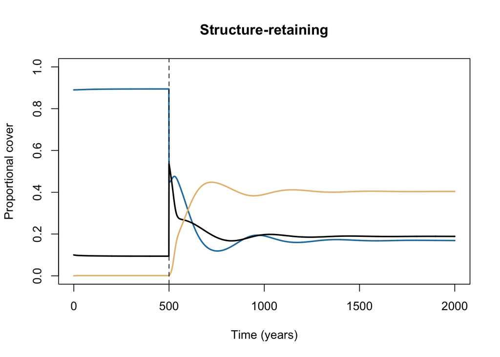

```r
# Create time vector, holding vectors for each state variable, and set initial conditions
C_L.simu_ret <- NaN*tset.disturb; C_L.simu_ret[1] <- 0.89
C_D.simu_ret <- NaN*tset.disturb; C_D.simu_ret[1] <- 0.1
M_E.simu_ret <- NaN*tset.disturb; M_E.simu_ret[1] <- 0
M_P.simu_ret <- NaN*tset.disturb; M_P.simu_ret[1] <- 0

# For() loop with if/else statement to simulate trajectories of spatial occupancy by live coral and macroalgae before and after disturbance
for(i in 2:length(tset.disturb)){ # For every element after the first in the time vector...

 if(tset.disturb[i] !=t_disturb){ # ...if the time point does not equal the time of disturbance, run the simulation as normal...

# calculate change in time
  dt <- tset.disturb[i] - tset.disturb[i-1]

  # Proportional cover at previous time step
  C_L <- C_L.simu_ret[i-1]
  C_D <- C_D.simu_ret[i-1]
  M_E <- M_E.simu_ret[i-1]
  M_P <- M_P.simu_ret[i-1]

# Change in proportional cover for live coral (C_L), dead coral (C_D), exposed macroalgae (M_E), and protected macroalgae (M_P)
  dC_L <- (dt)*(g_C*C_L*(1-C_L-C_D-M_E-M_P) + gamma_C*(1-C_L-C_D-M_E-M_P) - g_M_P_L*C_L*(M_E + M_P) - d_C*C_L)
  dC_D <- (dt)*(d_C*C_L + M_P*(h_M_E*(1-ref) + d_M) - g_M*C_D*(M_E + M_P) - gamma_M*C_D - e*C_D)
  dM_E <- (dt)*(g_M*M_E*(1-C_L-C_D-M_E-M_P) + g_M*M_P*(1-C_L-C_D-M_E-M_P) + gamma_M*(1-C_L-C_D-M_E-M_P) - M_E*(h_M_E + d_M))
  dM_P <- (dt)*(g_M*M_P*C_D + g_M*M_E*C_D + g_M_P_L*C_L*(M_E + M_P) + gamma_M*C_D - M_P*(h_M_E*(1-ref) + d_M + e))

# Proportional cover at new time step
  C_L.simu_ret[i] <- C_L.simu_ret[i-1] + dC_L
  C_D.simu_ret[i] <- C_D.simu_ret[i-1] + dC_D
  M_E.simu_ret[i] <- M_E.simu_ret[i-1] + dM_E
  M_P.simu_ret[i] <- M_P.simu_ret[i-1] + dM_P

  }

  # ... but if the time step does equal the time of disturbance...
    else {

  dt <- tset.disturb[i] - tset.disturb[i-1]

  C_L <- C_L.simu_ret[i-1]*0.5 # reduce live coral to 50% of its pre-disturbance level...
  C_D <- C_D.simu_ret[i-1] + (C_L.simu_ret[i-1]-C_L) #... and transfer this directly to the dead coral class
  M_E <- M_E.simu_ret[i-1]
  M_P <- M_P.simu_ret[i-1]

  dC_L <- (dt)*(g_C*C_L*(1-C_L-C_D-M_E-M_P) + gamma_C*(1-C_L-C_D-M_E-M_P) - g_M_P_L*C_L*(M_E + M_P) - d_C*C_L)
  dC_D <- (dt)*(d_C*C_L + M_P*(h_M_E*ref + d_M) - g_M*C_D*(M_E + M_P) - gamma_M*C_D - e*C_D)
  dM_E <- (dt)*(g_M*M_E*(1-C_L-C_D-M_E-M_P) + g_M*M_P*(1-C_L-C_D-M_E-M_P) + gamma_M*(1-C_L-C_D-M_E-M_P) - M_E*(h_M_E + d_M))
  dM_P <- (dt)*(g_M*M_P*C_D + g_M*M_E*C_D + g_M_P_L*C_L*(M_E + M_P) + gamma_M*C_D - M_P*(h_M_E*ref + d_M + e))

  C_L.simu_ret[i] <- C_L + dC_L
  C_D.simu_ret[i] <- C_D + dC_D
  M_E.simu_ret[i] <- M_E + dM_E
  M_P.simu_ret[i] <- M_P + dM_P

  }

}

# Plot of time series for all space holders
plot(tset.disturb, C_L.simu_ret, col = kotare[2], lwd = 2, lty = 'solid', type = 'l', xlab = "Time (years)", ylab = "Proportional cover", xlim = c(0, max(tset.disturb)), ylim = c(0, 1), main = "Structure-retaining")
lines(tset.disturb, C_D.simu_ret, col = "black", lwd = 2, lty = 'solid')
lines(tset.disturb, (M_E.simu_ret + M_P.simu_ret), col = kotare[3], lwd = 2, lty = 'solid') # Protected and exposed macroalgae combined to show cover of total macroalgae
abline(v=500, lty = 'dashed') # time of disturbance
```

### Creating a function for the model

Here, we create a function representing the model so that we don’t have to paste all that code in each time.

```r
tset <- seq(from = 0, to = 4000, by = 1)

CoralFun <- function(tset,ic,t_disturb,dist.type,disturbance_severity,g_C,gamma_C,g_M_P_L,d_C,h_M_E,ref,d_M,g_M,e,gamma_M){
  # create holding vectors for the inner loop
    C_L <- NaN*tset;    C_L[1] <- ic[1] # use the vector of initial conditions to populate initial densities
    C_D <- NaN*tset;    C_D[1] <- ic[2]
    M_E <- NaN*tset;    M_E[1] <- ic[3]
    M_P <- NaN*tset;    M_P[1] <- ic[4]

    # run ODE simulation
    for(i in 2:length(tset)){

  if(tset[i] !=t_disturb){ # if this is not a disturbance event

    # calculate change in proportional cover at each timestep
    dt <- tset[i] - tset[i-1]
    dC_L <- dt*(g_C*C_L[i-1]*(1-C_L[i-1]-C_D[i-1]-M_E[i-1]-M_P[i-1]) + gamma_C*(1-C_L[i-1]-C_D[i-1]-M_E[i-1]-M_P[i-1]) - g_M_P_L*C_L[i-1]*(M_E[i-1] + M_P[i-1]) - d_C*C_L[i-1])
    dC_D <- dt*(d_C*C_L[i-1] + M_P[i-1]*(h_M_E*(1-ref) + d_M) - g_M*C_D[i-1]*(M_E[i-1] + M_P[i-1]) - gamma_M*C_D[i-1] - e*C_D[i-1])
    dM_E <- dt*(g_M*M_E[i-1]*(1-C_L[i-1]-C_D[i-1]-M_E[i-1]-M_P[i-1]) + g_M*M_P[i-1]*(1-C_L[i-1]-C_D[i-1]-M_E[i-1]-M_P[i-1]) + gamma_M*(1-C_L[i-1]-C_D[i-1]-M_E[i-1]-M_P[i-1]) - M_E[i-1]*(h_M_E + d_M))
    dM_P <- dt*(g_M*M_P[i-1]*C_D[i-1] + g_M*M_E[i-1]*C_D[i-1] + g_M_P_L*C_L[i-1]*(M_E[i-1] + M_P[i-1]) + gamma_M*C_D[i-1] - M_P[i-1]*(h_M_E*(1-ref) + d_M + e))

    # calculate the population density at each timestep
    C_L[i] <- C_L[i-1] + dC_L
    C_D[i] <- C_D[i-1] + dC_D
    M_E[i] <- M_E[i-1] + dM_E
    M_P[i] <- M_P[i-1] + dM_P
    }

     else { # If the disturbance event is taking place, then adjust the populations accordingly
        if(dist.type == 'ret'){
          C_L[i] <- C_L[i-1]*(1-disturbance_severity)
          C_D[i] <- C_D[i-1] + C_L[i-1] - C_L[i]
          M_E[i] <- M_E[i-1]
          M_P[i] <- M_P[i-1]
        } else if(dist.type == 'none'){
          C_L[i] <- C_L[i-1]
          C_D[i] <- C_D[i-1]
          M_E[i] <- M_E[i-1]
          M_P[i] <- M_P[i-1]
          } else{
          C_L[i] <- C_L[i-1]*(1-disturbance_severity)
          C_D[i] <- C_D[i-1]*(1-disturbance_severity)
          M_E[i] <- M_E[i-1]*(1-disturbance_severity)
          M_P[i] <- M_P[i-1]*(1-disturbance_severity)
        }
     }
    }

    Results <- list("CL" = C_L, "CD" = C_D, "MS" = M_E, "MC" = M_P) # concatenate results into a list
    Results # report out that list
}
```

First consideration: What’s the starting point that you want to be disturbed from? Presumably, it’s one of the stable equilibria (either macroalgal-dominated, or coral-dominated). So you can skip the time you’re spending “ramping up” the simulation by just using the old equilibria as your initial condition and then having the perturbation occur right away.

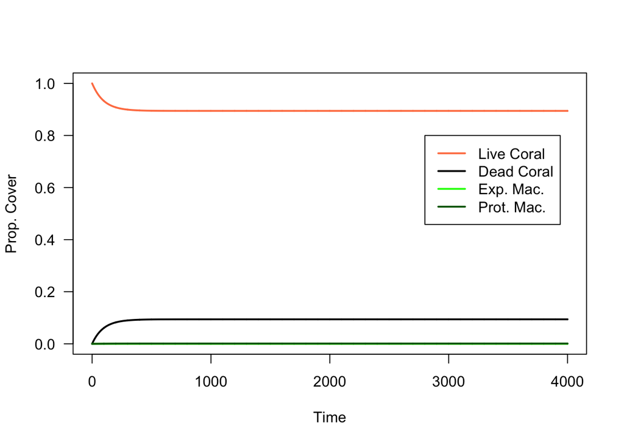

```r
# Find high-coral conditions:
Res <- CoralFun(tset,c(1,0,0,0),t_disturb,'none',disturbance_severity,g_C,gamma_C,g_M_P_L,d_C,h_M_E,ref,d_M,g_M,e,gamma_M)

plot(tset,Res$CL,las=1,xlab='Time',ylab='Prop. Cover',type='l',col='coral',lwd=2,ylim=c(0,1))
lines(tset,Res$CD,col='black',lwd=2)
lines(tset,Res$MS,col='green',lwd=2)
lines(tset,Res$MC,col='darkgreen',lwd=2)
legend(.7*max(tset),.8,legend=c('Live Coral','Dead Coral','Exp. Mac.','Prot. Mac.'),lwd=2,col=c('coral','black','green','darkgreen'))
```

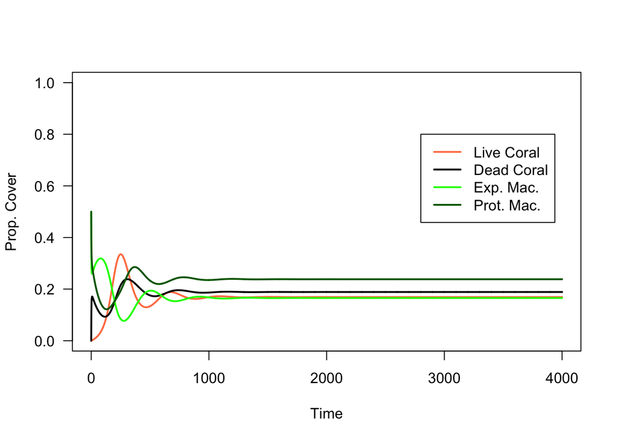

```r
ic.cor <- c(Res$CL[length(tset)],Res$CD[length(tset)],Res$MS[length(tset)],Res$MC[length(tset)])


# Find low-coral conditions:
Res <- CoralFun(tset,c(0,0,.5,.5),t_disturb,'none',disturbance_severity,g_C,gamma_C,g_M_P_L,d_C,h_M_E,ref,d_M,g_M,e,gamma_M)

plot(tset,Res$CL,las=1,xlab='Time',ylab='Prop. Cover',type='l',col='coral',lwd=2,ylim=c(0,1))
lines(tset,Res$CD,col='black',lwd=2)
lines(tset,Res$MS,col='green',lwd=2)
lines(tset,Res$MC,col='darkgreen',lwd=2)
legend(.7*max(tset),.8,legend=c('Live Coral','Dead Coral','Exp. Mac.','Prot. Mac.'),lwd=2,col=c('coral','black','green','darkgreen'))
```

```r
ic.mac <- c(Res$CL[length(tset)],Res$CD[length(tset)],Res$MS[length(tset)],Res$MC[length(tset)])
```

```r
t_disturb <- 1 # disturb immediately. (Note that we can't set this to time 0 because the initial conditions are what we put in there, and we start looping over t in the ODE solver from the 2nd step!)
t.step <- 1 # step size of time function
tset <- sort(unique(c(seq(from = 0, to = 6000, by = t.step),t_disturb))) # Time vector for ODE solutions. I'm using concatenate, uniqueness, and sorting to make sure that the "t-disturb" time is part of this vector. This would be robust to, for example, using the seq function with different "step sizes", etc.


# Choose disturbance type
dist.type <- "ret" # Structure-retaining disturbance
dist.type <- "rem" # Structure-removing disturbance
#dist.type <- "none" # No disturbance
```

As a slightly cleaner alternative, we could just perturb the initial conditions and not need to have the coral ODE function with disturbance cases at all!

```r
CoralFun.NoDisturb <- function(tset,ic,g_C,gamma_C,g_M_P_L,d_C,h_M_E,ref,d_M,g_M,e,gamma_M){
  # create holding vectors for the inner loop
    C_L <- NaN*tset;    C_L[1] <- ic[1] # use the vector of initial conditions to populate initial densities
    C_D <- NaN*tset;    C_D[1] <- ic[2]
    M_E <- NaN*tset;    M_E[1] <- ic[3]
    M_P <- NaN*tset;    M_P[1] <- ic[4]

    # run ODE simulation
    for(i in 2:length(tset)){

    # calculate change in proportional cover at each timestep
    dt <- tset[i] - tset[i-1]
    dC_L <- dt*(g_C*C_L[i-1]*(1-C_L[i-1]-C_D[i-1]-M_E[i-1]-M_P[i-1]) + gamma_C*(1-C_L[i-1]-C_D[i-1]-M_E[i-1]-M_P[i-1]) - g_M_P_L*C_L[i-1]*(M_E[i-1] + M_P[i-1]) - d_C*C_L[i-1])
    dC_D <- dt*(d_C*C_L[i-1] + M_P[i-1]*(h_M_E*(1-ref) + d_M) - g_M*C_D[i-1]*(M_E[i-1] + M_P[i-1]) - gamma_M*C_D[i-1] - e*C_D[i-1])
    dM_E <- dt*(g_M*M_E[i-1]*(1-C_L[i-1]-C_D[i-1]-M_E[i-1]-M_P[i-1]) + g_M*M_P[i-1]*(1-C_L[i-1]-C_D[i-1]-M_E[i-1]-M_P[i-1]) + gamma_M*(1-C_L[i-1]-C_D[i-1]-M_E[i-1]-M_P[i-1]) - M_E[i-1]*(h_M_E + d_M))
    dM_P <- dt*(g_M*M_P[i-1]*C_D[i-1] + g_M*M_E[i-1]*C_D[i-1] + g_M_P_L*C_L[i-1]*(M_E[i-1] + M_P[i-1]) + gamma_M*C_D[i-1] - M_P[i-1]*(h_M_E*(1-ref) + d_M + e)) ##REPLACED

    # calculate the population density at each timestep
    C_L[i] <- C_L[i-1] + dC_L
    C_D[i] <- C_D[i-1] + dC_D
    M_E[i] <- M_E[i-1] + dM_E
    M_P[i] <- M_P[i-1] + dM_P
    }

    Results <- list("CL" = C_L, "CD" = C_D, "ME" = M_E, "MP" = M_P) # concatenate results into a list
    Results # report out that list
}
```

## Computing disturbance thresholds

This code implements a binary search algorithm to find the disturbance threshold at which a system tips between equilibrium states.

```r
DistSevThresh.adapt <- function(ic.use,dist.type,tset,ic.dist,g_C,gamma_C,g_M_P_L,d_C,h_M_E,ref,d_M,g_M,e,gamma_M,iters){

  ## Step 1: Check full range of disturbance values (lower bound = 0, upper bound = 1, intermediate = 0.5)
  ## Step 1A: Check lower bound (disturbance = 0)
  dist_low <- 0
  # Adjust initial conditions based on the disturbance severity and type
  if(dist.type=='ret'){ic.dist <- c(ic.use[1]*(1-dist_low),ic.use[2]+ic.use[1]*dist_low,ic.use[3],ic.use[4])}
  if(dist.type=='rem'){ic.dist <- ic.use*(1-dist_low)}
  # Run the simulation
  Res <- CoralFun.NoDisturb(tset,ic.dist,g_C,gamma_C,g_M_P_L,d_C,h_M_E,ref,d_M,g_M,e,gamma_M)
  # Save the results
  Cstar_low <- Res$CL[length(tset)]

  ## Step 1B: Check upper bound (disturbance = 1)
  dist_high <- 1
  # Adjust initial conditions based on the disturbance severity and type
  if(dist.type=='ret'){ic.dist <- c(ic.use[1]*(1-dist_high),ic.use[2]+ic.use[1]*dist_high,ic.use[3],ic.use[4])}
  if(dist.type=='rem'){ic.dist <- ic.use*(1-dist_high)}
  # Run the simulation
  Res <- CoralFun.NoDisturb(tset,ic.dist,g_C,gamma_C,g_M_P_L,d_C,h_M_E,ref,d_M,g_M,e,gamma_M)
  # Save the results
  Cstar_high <- Res$CL[length(tset)]

  ## Step 1C: CHECKPOINT: Confirm that the disturbance extremes span a change in states. If they don't, return NaN.
  if(abs(Cstar_low - Cstar_high) < 0.001){ # If the two disturbances produce no change
    dist_test <- NaN
  } else{

  ## Step 1D: Check intermediate (disturbance = 0.5)
  dist_test <- (dist_low+dist_high)/2 # average of the two
  # Adjust initial conditions based on the disturbance severity and type
  if(dist.type=='ret'){ic.dist <- c(ic.use[1]*(1-dist_test),ic.use[2]+ic.use[1]*dist_test,ic.use[3],ic.use[4])}
  if(dist.type=='rem'){ic.dist <- ic.use*(1-dist_test)}
  # Run the simulation
  Res <- CoralFun.NoDisturb(tset,ic.dist,g_C,gamma_C,g_M_P_L,d_C,h_M_E,ref,d_M,g_M,e,gamma_M)
  # Save the results
  Cstar_test <- Res$CL[length(tset)]


  ## Step 2: Figure out which two disturbance levels flank the tipping point, and update the high and low bounds
  if(abs(Cstar_test - Cstar_low) < 0.001){ # If the test coral biomass is pretty darn close to the lower bound, then this can be the new lower bound
    dist_low <- dist_test # save the new lower bound
    Cstar_low <- Cstar_test # and the new test Cstar value
  } else{ # Otherwise, this should be the new upper bound
    dist_high <- dist_test # save the new upper bound
    Cstar_high <- Cstar_test # save the new Cstar value
  }


  ## Step 3: Iterate this algorithm, narrowing down on the "correct" disturbance threshold.
  for(j in 1:iters){ # for each iteration
    ## Step 3A: Compute a new test disturbance level, and its corresponding coral cover
    dist_test <- (dist_low+dist_high)/2 # average of the two
    # Adjust initial conditions based on the disturbance severity and type
    if(dist.type=='ret'){ic.dist <- c(ic.use[1]*(1-dist_test),ic.use[2]+ic.use[1]*dist_test,ic.use[3],ic.use[4])}
    if(dist.type=='rem'){ic.dist <- ic.use*(1-dist_test)}
    # Run the simulation
    Res <- CoralFun.NoDisturb(tset,ic.dist,g_C,gamma_C,g_M_P_L,d_C,h_M_E,ref,d_M,g_M,e,gamma_M)
    # Save the results
    Cstar_test <- Res$CL[length(tset)]

    ## Step 3B: Update previous estimates
    if(abs(Cstar_test - Cstar_low) < 0.001){ # If the test coral biomass is pretty darn close to the lower bound, then this can be the new lower bound
      dist_low <- dist_test # save the new lower bound
      Cstar_low <- Cstar_test # and the new test Cstar value
    } else{ # Otherwise, this should be the new upper bound
      dist_high <- dist_test # save the new upper bound
      Cstar_high <- Cstar_test # save the new Cstar value
    }}
  }


  # Report out the results
  Results2 <- list("dist.thresh" = dist_test)

  Results2

}
```

Let’s take this function out for a spin!

```r
  Res <- CoralFun.NoDisturb(tset,c(1,0,0,0),g_C,gamma_C,g_M_P_L,d_C,h_M_E,ref,d_M,g_M,e,gamma_M)
  ic.cor <- c(Res$CL[length(tset)],Res$CD[length(tset)],Res$ME[length(tset)],Res$MP[length(tset)])

ic.use <- ic.cor
dist.type <- "ret"

iters.set <- seq(1,25,by=1)
thresh.set <- NaN*iters.set

for(k in 1:length(iters.set)){
  iters <- iters.set[k]
  Res2 <- DistSevThresh.adapt(ic.use,dist.type,tset,ic.dist,g_C,gamma_C,g_M_P_L,d_C,h_M_E,ref,d_M,g_M,e,gamma_M,iters)
  thresh.set[k] <- Res2$dist.thresh}
```

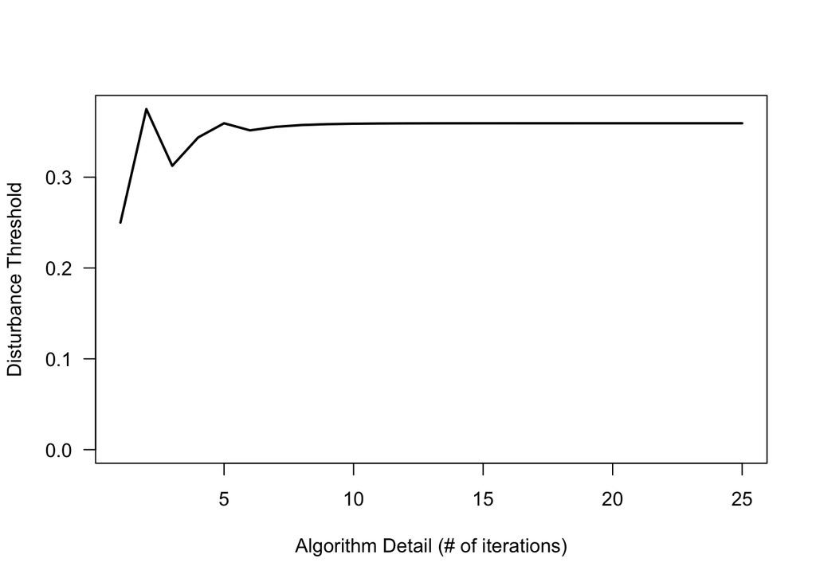

```r
plot(iters.set,thresh.set,las=1,lwd=2,type='l',ylim=c(0,max(thresh.set)),xlab='Algorithm Detail (# of iterations)', ylab='Disturbance Threshold')
```

Woohoo! This is wicked fast, and very efficient. So let’s use it to re-make the other figures.

```r
# Step 1: Choose the parameter to vary, and range over which to vary it
ref_set <- seq(from = 0, to = 1, by = 0.01)
#ref_set2 <- seq(from = 0, to = 1, by = 0.01)

# Step 1a: Create associated holding variables
CtoM.ret.set<- NaN*ref_set
CtoM.rem.set <- NaN*ref_set
MtoC.ret.set <- NaN*ref_set
MtoC.rem.set <- NaN*ref_set
C.eq.set <- NaN*ref_set
M.eq.set <- NaN*ref_set

# Step 1b: Some other setup
iters <- 10 # number of iterations to "narrow down" on the disturbance threshold
tset <- seq(from = 0, to = 3000, by = t.step)

# Loop through each of the parameter values
for(ctr2 in 1:length(ref_set)){

  ref <- ref_set[ctr2]

  # Step 2: Find new equilibria (new initial conditions for coral and macroalgal dominated states)
  Res <- CoralFun.NoDisturb(tset,c(1,0,0,0),g_C,gamma_C,g_M_P_L,d_C,h_M_E,ref,d_M,g_M,e,gamma_M)
  ic.cor <- c(Res$CL[length(tset)],Res$CD[length(tset)],Res$ME[length(tset)],Res$MP[length(tset)])
  C.eq.set[ctr2] <- Res$CL[length(tset)] # Record the equilibrium coral abundance in the coral-dominated state

  # Find low-coral conditions:
  Res <- CoralFun.NoDisturb(tset,c(0,0,.5,.5),g_C,gamma_C,g_M_P_L,d_C,h_M_E,ref,d_M,g_M,e,gamma_M)
  ic.mac <- c(Res$CL[length(tset)],Res$CD[length(tset)],Res$ME[length(tset)],Res$MP[length(tset)])
  M.eq.set[ctr2] <- Res$CL[length(tset)] # Record the equilibrium coral abundance in the macroalgal-dominated state

  # Step 3: Find the tipping points
  if(abs(C.eq.set[ctr2] -M.eq.set[ctr2]) > 0.001){ # Only bother finding tipping points if there are two stable equilibria (e.g., the coral cover in coral and macroalgal dominated systems is different)

    # Step 3A: Find the tipping point from coral to macroalgal dominance with biological disturbance
    ic.use <- ic.cor # start with a coral dominated system
    dist.type <- "ret" # use a biological disturbance
    Res2 <- DistSevThresh.adapt(ic.use,dist.type,tset,ic.dist,g_C,gamma_C,g_M_P_L,d_C,h_M_E,ref,d_M,g_M,e,gamma_M,iters)
    CtoM.ret.set[ctr2] <- Res2$dist.thresh # Record the result

    # Step 3B: Find the tipping point from coral to macroalgal dominance with structure-removing disturbance
    ic.use <- ic.cor # start with a coral dominated system
    dist.type <- "rem" # use a biological disturbance
    Res2 <- DistSevThresh.adapt(ic.use,dist.type,tset,ic.dist,g_C,gamma_C,g_M_P_L,d_C,h_M_E,ref,d_M,g_M,e,gamma_M,iters)
    CtoM.rem.set[ctr2] <- Res2$dist.thresh # Record the result

    # Step 3C: Find the tipping point from M to C dominance with biological disturbance
    ic.use <- ic.mac # start with a coral dominated system
    dist.type <- "ret" # use a biological disturbance
    Res2 <- DistSevThresh.adapt(ic.use,dist.type,tset,ic.dist,g_C,gamma_C,g_M_P_L,d_C,h_M_E,ref,d_M,g_M,e,gamma_M,iters)
    MtoC.ret.set[ctr2] <- Res2$dist.thresh # Record the result

    # Step 3D: Find the tipping point from M to C dominance with structure-removing disturbance
    ic.use <- ic.mac # start with a coral dominated system
    dist.type <- "rem" # use a biological disturbance
    Res2 <- DistSevThresh.adapt(ic.use,dist.type,tset,ic.dist,g_C,gamma_C,g_M_P_L,d_C,h_M_E,ref,d_M,g_M,e,gamma_M,iters)
    MtoC.rem.set[ctr2] <- Res2$dist.thresh # Record the result
  }

}
```

Find tipping points in disturbance severity for each transition type within the region of bistability:

```r
# Line for tipping points going from coral to macroalgae for structure-retaining disturbances
for( i in 1:length(CtoM.ret.set)){
  if(i < 50){
    if (is.na(CtoM.ret.set)[i]){
      CtoM.ret.set[i] <- 1
    } } else {
      if(is.na(CtoM.ret.set)[i]){
      CtoM.ret.set[i] <- 0

    }
  }
}

# # Line for tipping points going from macroalgae to coral for structure-retaining disturbances; this transition type does not occur as a result of disturbance and therefore is commented out
# for( i in 1:length(MtoC.ret.set)){
#   if(i < 50){
#     if (is.na(MtoC.ret.set)[i]){
#       MtoC.ret.set[i] <- 0
#     } } else {
#       if(is.na(MtoC.ret.set)[i]){
#       MtoC.ret.set[i] <- 1
#
#     }
#   }
# }

# Line for tipping points going from coral to macroalgae for structure-removing disturbances
for( i in 1:length(CtoM.rem.set)){
  if(i < 50){
    if (is.na(CtoM.rem.set)[i]){
      CtoM.rem.set[i] <- 1
    } } else {
      if(is.na(CtoM.rem.set)[i]){
      CtoM.rem.set[i] <- 1

    }
  }
}

# Line for tipping points going from Macroalgae to coral for structure-removing disturbances
for( i in 1:length(MtoC.rem.set)){
  if(i < 50){
    if (is.na(MtoC.rem.set)[i]){
      MtoC.rem.set[i] <- 0
    } } else {
      if(is.na(MtoC.rem.set)[i]){
      MtoC.rem.set[i] <- 1

    }
  }
}
```

Creates a new function that returns time to equilibrium:

```r
ReturnTime <- function(ic.cor,ic.mac,tset,ic,g_C,gamma_C,g_M_P_L,d_C,h_M_E,ref,d_M,g_M,e,gamma_M){
  # Create holding vectors for the inner loop
    C_L <- NaN*tset;    C_L[1] <- ic[1] # use the vector of initial conditions to populate initial densities
    C_D <- NaN*tset;    C_D[1] <- ic[2]
    M_E <- NaN*tset;    M_E[1] <- ic[3]
    M_P <- NaN*tset;    M_P[1] <- ic[4]

  # Run simulation
  for(i in 2:length(tset)){
    dt <- tset[i] - tset[i-1]
    C_L[i] <- C_L[i-1] + dt*(g_C*C_L[i-1]*(1-C_L[i-1]-C_D[i-1]-M_E[i-1]-M_P[i-1]) + gamma_C*(1-C_L[i-1]-C_D[i-1]-M_E[i-1]-M_P[i-1]) - g_M_P_L*C_L[i-1]*(M_E[i-1] + M_P[i-1]) - d_C*C_L[i-1])
    C_D[i] <- C_D[i-1] + dt*(d_C*C_L[i-1] + M_P[i-1]*(h_M_E*(1-ref) + d_M) - g_M*C_D[i-1]*(M_E[i-1] + M_P[i-1]) - gamma_M*C_D[i-1] - e*C_D[i-1])
    M_E[i] <- M_E[i-1] + dt*(g_M*M_E[i-1]*(1-C_L[i-1]-C_D[i-1]-M_E[i-1]-M_P[i-1]) + g_M*M_P[i-1]*(1-C_L[i-1]-C_D[i-1]-M_E[i-1]-M_P[i-1]) + gamma_M*(1-C_L[i-1]-C_D[i-1]-M_E[i-1]-M_P[i-1]) - M_E[i-1]*(h_M_E + d_M))
    M_P[i] <- M_P[i-1] + dt*(g_M*M_P[i-1]*C_D[i-1] + g_M*M_E[i-1]*C_D[i-1] + g_M_P_L*C_L[i-1]*(M_E[i-1] + M_P[i-1]) + gamma_M*C_D[i-1] - M_P[i-1]*(h_M_E*(1-ref) + d_M + e))
    }

  # Determine which equilibrium you go to
  if (abs(C_L[length(tset)]-ic.cor[1]) < 0.001) {EqCorUse <- ic.cor[1]; EqMacUse <- ic.cor[3]; EqCDUse <- ic.cor[2]; EqMCUse <- ic.cor[4]; Eq = 1} else {EqCorUse <- ic.mac[1]; EqMacUse <- ic.mac[3]; EqCDUse <- ic.mac[2]; EqMCUse <- ic.mac[4]; Eq = 2}
    if(C_L[length(tset)] < .5){Eq = 2} # Modification: If coral abundance is below 0.5, then assume it's macroalgal dominated. CAUTION!!! Check this carefully because if you choose different parameters, this threshold might be different.

  # Figure out how long it took to get there
  RetTime <- tset[which(tset*(abs(C_L-EqCorUse) + abs(M_E-EqMacUse) + abs(C_D-EqCDUse) + abs(M_P-EqMCUse) < 0.004) != 0)[1]] # Which is the first timestep that you're near the equilibrium?

  Results <- list("RetTime" = RetTime,"CL" = C_L, "CD" = C_D, "MS" = M_E, "MC" = M_P,"Eq" = Eq)
  Results
}
```

Now we have to loop over all the parameter values:

```r
# Step 1: Choose the parameter to vary, and range over which to vary it
ref_set <- seq(from = 0, to = 1, by = 0.01)

# Step 2: Choose the disturbance distance to loop over
dist.prop.set <- seq(from = 0, to = 1, by = 0.01) # Vector of disturbance intensities to test

# Step 3: Create associated holding variables
C.rem.eq.set <- matrix(rep(NaN,length(ref_set)*length(dist.prop.set)),nrow=length(ref_set),ncol=length(dist.prop.set)) # equilibrium for structure-removing disturbance starting in a coral-dominated state
C.rem.time.set <- C.rem.eq.set # equilibration time for a structure-removing disturbance starting in a coral-dominated state
M.ret.eq.set <- C.rem.eq.set
M.ret.time.set <- C.rem.eq.set
C.ret.eq.set <- C.rem.eq.set
C.ret.time.set <- C.rem.eq.set
M.rem.eq.set <- C.rem.eq.set
M.rem.time.set <- C.rem.eq.set

C.eq.set <- NaN*ref_set
M.eq.set <- NaN*ref_set

# Step 4: Some other setup
tset <- seq(from = 0, to = 4000, by =1) #was to = 3000

# Loop through each of the parameter values
for(varctr in 1:length(ref_set)){

  ref <- ref_set[varctr]

  # Step 5: Find new equilibria (new initial conditions for coral and macroalgal dominated states)
  Res <- CoralFun.NoDisturb(tset,c(1,0,0,0),g_C,gamma_C,g_M_P_L,d_C,h_M_E,ref,d_M,g_M,e,gamma_M)
  ic.cor <- c(Res$CL[length(tset)],Res$CD[length(tset)],Res$ME[length(tset)],Res$MP[length(tset)])
  C.eq.set[varctr] <- Res$CL[length(tset)] # Record the equilibrium coral abundance in the coral-dominated state

  # Find low-coral conditions:
  Res <- CoralFun.NoDisturb(tset,c(0,0,.5,.5),g_C,gamma_C,g_M_P_L,d_C,h_M_E,ref,d_M,g_M,e,gamma_M)
  ic.mac <- c(Res$CL[length(tset)],Res$CD[length(tset)],Res$ME[length(tset)],Res$MP[length(tset)])
  M.eq.set[varctr] <- Res$CL[length(tset)] # Record the equilibrium coral abundance in the macroalgal-dominated state

  # Step 6: Find the return times & which equilibrium you return to
  if(abs(C.eq.set[varctr] -M.eq.set[varctr]) > 0.001){ # Only bother finding tipping points if there are two stable equilibria (e.g., the coral cover in coral and macroalgal dominated systems is different)

    for(distctr in 1:length(dist.prop.set)){
    dist.use <- dist.prop.set[distctr]
    # Step 6A: Find the equilibration time from coral dominance with biological disturbance
    ic.dist <- c(ic.cor[1]*(1-dist.use),ic.cor[2]+ic.cor[1]*dist.use,ic.cor[3],ic.cor[4]) # start with a coral dominated system
    Res2 <- ReturnTime(ic.cor,ic.mac,tset,ic.dist,g_C,gamma_C,g_M_P_L,d_C,h_M_E,ref,d_M,g_M,e,gamma_M)
    C.ret.eq.set[varctr,distctr] <- Res2$Eq # Record the result
    C.ret.time.set[varctr,distctr] <- Res2$RetTime # Record the result

    # Step 6B: Find the equilibration time from coral dominance with structure-removing disturbance
    ic.dist <- ic.cor*(1-dist.use)
    Res2 <- ReturnTime(ic.cor,ic.mac,tset,ic.dist,g_C,gamma_C,g_M_P_L,d_C,h_M_E,ref,d_M,g_M,e,gamma_M)
    C.rem.eq.set[varctr,distctr] <- Res2$Eq # Record the result
    C.rem.time.set[varctr,distctr] <- Res2$RetTime # Record the result

    # Step 6C: Find the equilibration time from M dominance with biological disturbance
    ic.dist <- c(ic.mac[1]*(1-dist.use),ic.mac[2]+ic.mac[1]*dist.use,ic.mac[3],ic.mac[4]) # start with a macroalgal dominated system
    Res2 <- ReturnTime(ic.cor,ic.mac,tset,ic.dist,g_C,gamma_C,g_M_P_L,d_C,h_M_E,ref,d_M,g_M,e,gamma_M)
    M.ret.eq.set[varctr,distctr] <- Res2$Eq # Record the result
    M.ret.time.set[varctr,distctr] <- Res2$RetTime # Record the result

    # Step 6D: Find the equilibration time from M dominance with structure-removing disturbance
    ic.dist <- ic.mac*(1-dist.use) # start with a macroalgal-dominated system
    Res2 <- ReturnTime(ic.cor,ic.mac,tset,ic.dist,g_C,gamma_C,g_M_P_L,d_C,h_M_E,ref,d_M,g_M,e,gamma_M)
    M.rem.eq.set[varctr,distctr] <- Res2$Eq # Record the result
    M.rem.time.set[varctr,distctr] <- Res2$RetTime # Record the result
  }}

}
```

#### Figure 5: Equilibrium state and time as a funciton of disturbance intensity and algal protection

The following code chunks create plots displaying the equilibrium state of the system AFTER disturbance as a function of algal protection and the intensity of disturbance. We ran simulations both for coral-dominated and macroalgae dominated initial conditions, and for both structure removing and structure-retaining disturbances.

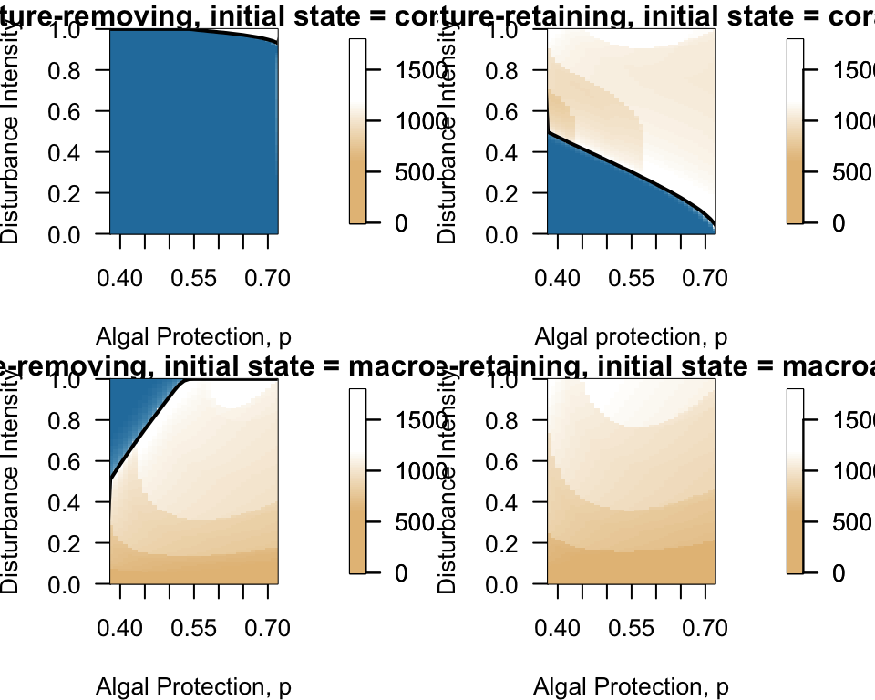

```r
require(fields) # has image.plot function
par(mar=c(4,3.8,1,5.5),mfrow=c(2,2))

# Sets limits for minimum and maximum values on heat maps
zlimits <- c(min(C.ret.time.set,na.rm=T),max(C.ret.time.set,na.rm=T))

# Top left -- coral initial state w/ structure-removing disturbance
C.rem.time.set.toC <- NaN*C.rem.time.set
C.rem.time.set.toM <- NaN*C.rem.time.set
for(i in 1:dim(C.rem.eq.set)[1]){
  for(j in 1:dim(C.rem.eq.set)[2]){
    if(!is.nan(C.rem.eq.set[i,j])){
    if(C.rem.eq.set[i,j] == 1){ C.rem.time.set.toC[i,j] <- C.rem.time.set[i,j] } # If it's a coral equilibrium, save it to the "to coral" file
    if(C.rem.eq.set[i,j] == 2){ C.rem.time.set.toM[i,j] <- C.rem.time.set[i,j] } # If it's a macroalgae equilibrium, save it to the "to macroalgae" file
  }}
}

macroalgae.col <- colorRampPalette(colors = c(kotare[3],kotare[3],'white','white'))
coral.col <- colorRampPalette(colors = c(kotare[2],kotare[2],'white','white'))

image.plot(x = ref_set, y = dist.prop.set, z = C.rem.time.set.toC ,las=1,col=coral.col(100),xlab= "Algal Protection, p",ylab="Disturbance Intensity",xlim=c(0.38,0.72), ylim=c(0,1), zlim=zlimits, main = 'Structure-removing, initial state = coral')
image.plot(x = ref_set, y = dist.prop.set, z = C.rem.time.set.toM ,las=1,col=macroalgae.col(100),add=T,zlim=zlimits,xlim=c(0.38,0.72), ylim=c(0,1))
CtoM.rem.set2 <- CtoM.rem.set
CtoM.rem.set2[CtoM.rem.set2==0] <- 1
lines(ref_set, CtoM.rem.set2, lwd=2, col = "black")

# Top right -- coral initial state w/ structure retaining disturbance
C.ret.time.set.toC <- NaN*C.ret.time.set
C.ret.time.set.toM <- NaN*C.ret.time.set
for(i in 1:dim(C.ret.eq.set)[1]){
  for(j in 1:dim(C.ret.eq.set)[2]){
    if(!is.nan(C.ret.eq.set[i,j])){
    if(C.ret.eq.set[i,j] == 1){ C.ret.time.set.toC[i,j] <- C.ret.time.set[i,j] } # If it's a coral equilibrium, save it to the "to coral" file
    if(C.ret.eq.set[i,j] == 2){ C.ret.time.set.toM[i,j] <- C.ret.time.set[i,j] } # If it's a macroalgae equilibrium, save it to the "to macroalgae" file
  }}
}

macroalgae.col <- colorRampPalette(colors = c(kotare[3],kotare[3],'white','white'))
coral.col <- colorRampPalette(colors = c(kotare[2],kotare[2],'white','white'))

image.plot(x = ref_set, y = dist.prop.set, z = C.ret.time.set.toC ,las=1,col=coral.col(100),xlab='Algal protection, p',ylab='Disturbance Intensity',xlim=c(0.38,0.72), ylim=c(0,1), zlim=zlimits, main = 'Structure-retaining, initial state = coral')
image.plot(x = ref_set, y = dist.prop.set, z = C.ret.time.set.toM ,las=1,col=macroalgae.col(100),add=T,zlim=zlimits,xlim=c(0.38,0.72),ylim=c(0,1))
lines(ref_set, CtoM.ret.set, lwd=2, col = 'black')

# Bottom left -- macroalgal initial state w/ structure removing disturbance
M.rem.time.set.toC <- NaN*M.rem.time.set
M.rem.time.set.toM <- NaN*M.rem.time.set
for(i in 1:dim(M.rem.eq.set)[1]){
  for(j in 1:dim(M.rem.eq.set)[2]){
    if(!is.nan(M.rem.eq.set[i,j])){
    if(M.rem.eq.set[i,j] == 1){ M.rem.time.set.toC[i,j] <- M.rem.time.set[i,j] } # If it's a coral equilibrium, save it to the "to coral" file
    if(M.rem.eq.set[i,j] == 2){ M.rem.time.set.toM[i,j] <- M.rem.time.set[i,j] } # If it's a macroalgae equilibrium, save it to the "to macroalgae" file
  }}
}

macroalgae.col <- colorRampPalette(colors = c(kotare[3],kotare[3],'white','white'))
coral.col <- colorRampPalette(colors = c(kotare[2],kotare[2],'white','white'))

image.plot(x = ref_set, y = dist.prop.set, z = M.rem.time.set.toC ,las=1,col=coral.col(100),xlab='Algal Protection, p',ylab='Disturbance Intensity',xlim=c(0.38,0.72), ylim=c(0,1), zlim=zlimits, main = 'Structure-removing, initial state = macroalgae')
image.plot(x = ref_set, y = dist.prop.set, z = M.rem.time.set.toM ,las=1,col=macroalgae.col(100),add=T,zlim=zlimits,xlim=c(0.38,0.72),ylim=c(0,100))
lines(ref_set, MtoC.rem.set, lwd=2, col = 'black')

# Bottom right -- macroalgal initial state w/ structure-retaining disturbance
M.ret.time.set.toC <- NaN*M.ret.time.set
M.ret.time.set.toM <- NaN*M.ret.time.set
for(i in 1:dim(M.ret.eq.set)[1]){
  for(j in 1:dim(M.ret.eq.set)[2]){
    if(!is.nan(M.ret.eq.set[i,j])){
    if(M.ret.eq.set[i,j] == 1){ M.ret.time.set.toC[i,j] <- M.ret.time.set[i,j] } # If it's a coral equilibrium, save it to the "to coral" file
    if(M.ret.eq.set[i,j] == 2){ M.ret.time.set.toM[i,j] <- M.ret.time.set[i,j] } # If it's a macroalgae equilibrium, save it to the "to macroalgae" file
  }}
}

macroalgae.col <- colorRampPalette(colors = c(kotare[3],kotare[3],'white','white'))
coral.col <- colorRampPalette(colors = c(kotare[2],kotare[2],'white','white'))

image.plot(x = ref_set, y = dist.prop.set, z = M.ret.time.set.toC ,las=1,col=coral.col(100),xlab='Algal Protection, p',ylab='Disturbance Intensity',xlim=c(0.38,0.72), ylim=c(0,1), zlim=zlimits, main = 'Structure-retaining, initial state = macroalgae')
image.plot(x = ref_set, y = dist.prop.set, z = M.ret.time.set.toM ,las=1,col=macroalgae.col(100),add=T,zlim=zlimits,xlim=c(0.38,0.72),ylim=c(0,1))
```